# Part II - (Prosper Loan Dataset)

## by (Rita Chukwuma)

## Investigation Overview

> During this investigation, I focus mainly on finding out the variables that influences borrowers APR and investors Estimated return. I started by introducing the estimated return by plotting its distribution and I tried calculating the actual return by using Prosper's Net Annualized formula but couldn’t get accurate result due to some other factors that are far-fetched. However, I used various plots, to explore extensively on the relationship among all my variables of interest, particularly: BorowersAPR, stated monthly income, loan amount, EstimatedReturn, ProsperScore.

## Dataset Overview

> The Prosper loan dataset comprises of 113937 loan entries with 81 attributes on each loan, including loan amount, borrower rate, borrower income, current loan status etc, from the year 2009-2014.

> The dataset is subdivided into two main categories:

> The borrower information: Basic attributes of the borrowers such as stated monthly income, income range, employment status, interest rate, loan status, Bank card Utilization etc. The Loan performance information: Metrics evaluating the risk associated with the loans such as Prosper Rating and Estimated Returns, Prosper Score etc.

```
(113937, 8)
```

## (Visualization 1)

> The plot shows the distribution is right skewed. It also looks like there are some peaks at 5%, 7.5%, 8.0%, 0.1% and 12.5%. However, the largest bin falls right around 12.5%.

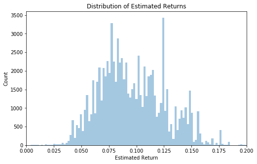

## (Visualization 2)

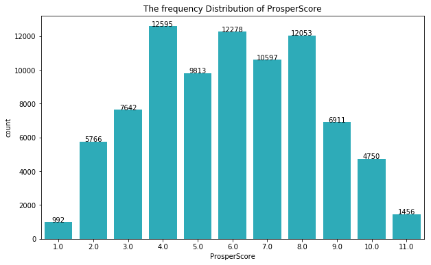

## (Visualization 3)

Here we have a normal distribution with a peak at around 0.2 and an exceptional high counts between 0.35% and 0.358%. The plot looks not too skewed.

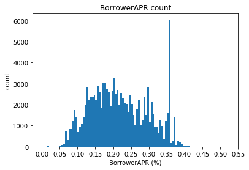

## (Visualization 4)

> The plot below shows us how an increase in BorrowerAPR causes an Increase in Estimated Return while high prosper score brings a decrease on Estimated Return.

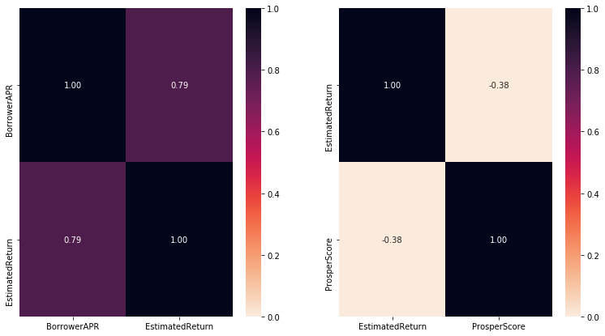

## (Visualization 5)

In this plot both Stated Monthly Income and Loan Original Amount are negatively correlated to BorrowerAPR. An increase in income brings about an increase in loan amount and eventually a decrease in BorrowerAPR.

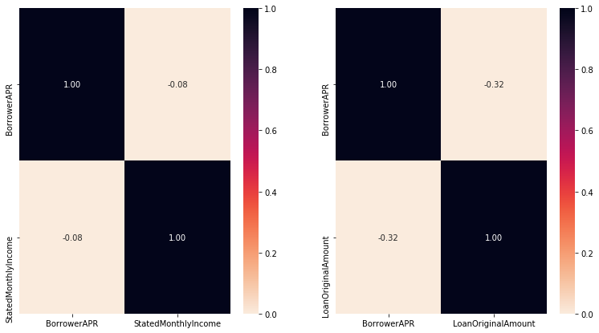